# Data Exploration: Investigating the Relationship Between Poverty Probability and Key Variables

## Importing the libraries

```python
import pandas as pd, numpy as np
import seaborn as sns
import matplotlib.pyplot as plt
%matplotlib inline
import warnings

# Suppress FutureWarnings
warnings.filterwarnings("ignore", category=FutureWarning)
warnings.filterwarnings("ignore", category=UserWarning)
```

## Merge Datasets

```python
df1 = pd.read_csv("train_values.csv")
df2 = pd.read_csv("train_labels.csv")

df = df1.merge(df2, on = 'row_id')
```

```python
df.info()
```

```
<class 'pandas.core.frame.DataFrame'>
RangeIndex: 12600 entries, 0 to 12599
Data columns (total 60 columns):
 #   Column                                 Non-Null Count  Dtype
---  ------                                 --------------  -----
 0   row_id                                 12600 non-null  int64
 1   country                                12600 non-null  object
 2   is_urban                               12600 non-null  bool
 3   age                                    12600 non-null  float64
 4   female                                 12600 non-null  bool
 5   married                                12600 non-null  bool
 6   religion                               12600 non-null  object
 7   relationship_to_hh_head                12600 non-null  object
 8   education_level                        12364 non-null  float64
 9   literacy                               12600 non-null  bool
```

[output cut: 52 more lines]

```python
df.isnull().sum()
```

```
row_id                                       0
country                                      0
is_urban                                     0
age                                          0
female                                       0
married                                      0
religion                                     0
relationship_to_hh_head                      0
education_level                            236
literacy                                     0
can_add                                      0
can_divide                                   0
can_calc_percents                            0
can_calc_compounding                         0
employed_last_year                           0
employment_category_last_year                0
employment_type_last_year                    0
share_hh_income_provided                   305
income_ag_livestock_last_year                0
income_friends_family_last_year              0
income_government_last_year                  0
income_own_business_last_year                0
income_private_sector_last_year              0
income_public_sector_last_year               0
num_times_borrowed_last_year                 0
borrowing_recency                            0
formal_savings                               0
informal_savings                             0
cash_property_savings                        0
has_insurance                                0
has_investment                               0
bank_interest_rate                       12311
mm_interest_rate                         12449
mfi_interest_rate                        12399
other_fsp_interest_rate                  12361
num_shocks_last_year                         0
avg_shock_strength_last_year                 0
borrowed_for_emergency_last_year             0
borrowed_for_daily_expenses_last_year        0
borrowed_for_home_or_biz_last_year           0
phone_technology                             0
can_call                                     0
can_text                                     0
can_use_internet                             0
can_make_transaction                         0
phone_ownership                              0
advanced_phone_use                           0
reg_bank_acct                                0
reg_mm_acct                                  0
reg_formal_nbfi_account                      0
financially_included                         0
active_bank_user                             0
active_mm_user                               0
active_formal_nbfi_user                      0
active_informal_nbfi_user                    0
nonreg_active_mm_user                        0
num_formal_institutions_last_year            0
num_informal_institutions_last_year          0
num_financial_activities_last_year           0
poverty_probability                          0
dtype: int64
```

```python
df.drop(['bank_interest_rate', 'mm_interest_rate', 'mfi_interest_rate', 'other_fsp_interest_rate'], axis = 1)
```

|  | row_id | country | is_urban | age | female | married | religion | relationship_to_hh_head | education_level | literacy | ... | financially_included | active_bank_user | active_mm_user | active_formal_nbfi_user | active_informal_nbfi_user | nonreg_active_mm_user | num_formal_institutions_last_year | num_informal_institutions_last_year | num_financial_activities_last_year | poverty_probability |
| --- | --- | --- | --- | --- | --- | --- | --- | --- | --- | --- | --- | --- | --- | --- | --- | --- | --- | --- | --- | --- | --- |
| 0 | 0 | C | False | 18.0 | True | True | P | Other | 1.0 | True | ... | True | True | False | False | False | False | 1 | 0 | 1 | 0.515 |
| 1 | 1 | C | True | 30.0 | True | True | P | Other | 1.0 | True | ... | True | True | False | False | False | False | 1 | 0 | 0 | 0.981 |
| 2 | 2 | A | False | 20.0 | True | True | Q | Spouse | 1.0 | True | ... | False | False | False | False | False | False | 0 | 0 | 0 | 0.982 |
| 3 | 3 | A | False | 61.0 | False | True | Q | Head | 0.0 | False | ... | False | False | False | False | False | False | 0 | 0 | 0 | 0.879 |
| 4 | 4 | D | False | 26.0 | True | True | X | Spouse | 1.0 | True | ... | False | False | False | False | False | False | 1 | 0 | 3 | 0.796 |
| ... | ... | ... | ... | ... | ... | ... | ... | ... | ... | ... | ... | ... | ... | ... | ... | ... | ... | ... | ... | ... | ... |
| 12595 | 12595 | C | True | 50.0 | False | True | P | Head | 1.0 | True | ... | True | False | False | False | False | False | 2 | 0 | 1 | 0.990 |
| 12596 | 12596 | D | False | 90.0 | False | False | O | Head | 0.0 | True | ... | False | False | False | False | False | False | 0 | 0 | 0 | 0.950 |
| 12597 | 12597 | J | False | 52.0 | True | False | X | Head | 1.0 | False | ... | True | False | False | False | True | False | 0 | 1 | 0 | 0.342 |
| 12598 | 12598 | I | False | 40.0 | False | True | Q | Head | 0.0 | False | ... | False | False | False | False | False | False | 0 | 0 | 0 | 0.846 |
| 12599 | 12599 | D | True | 24.0 | False | False | X | Son/Daughter | 2.0 | True | ... | True | True | True | True | False | False | 3 | 0 | 6 | 0.569 |

12600 rows × 56 columns

```python
df.head()
```

|  | row_id | country | is_urban | age | female | married | religion | relationship_to_hh_head | education_level | literacy | ... | financially_included | active_bank_user | active_mm_user | active_formal_nbfi_user | active_informal_nbfi_user | nonreg_active_mm_user | num_formal_institutions_last_year | num_informal_institutions_last_year | num_financial_activities_last_year | poverty_probability |
| --- | --- | --- | --- | --- | --- | --- | --- | --- | --- | --- | --- | --- | --- | --- | --- | --- | --- | --- | --- | --- | --- |
| 0 | 0 | C | False | 18.0 | True | True | P | Other | 1.0 | True | ... | True | True | False | False | False | False | 1 | 0 | 1 | 0.515 |
| 1 | 1 | C | True | 30.0 | True | True | P | Other | 1.0 | True | ... | True | True | False | False | False | False | 1 | 0 | 0 | 0.981 |
| 2 | 2 | A | False | 20.0 | True | True | Q | Spouse | 1.0 | True | ... | False | False | False | False | False | False | 0 | 0 | 0 | 0.982 |
| 3 | 3 | A | False | 61.0 | False | True | Q | Head | 0.0 | False | ... | False | False | False | False | False | False | 0 | 0 | 0 | 0.879 |
| 4 | 4 | D | False | 26.0 | True | True | X | Spouse | 1.0 | True | ... | False | False | False | False | False | False | 1 | 0 | 3 | 0.796 |

5 rows × 60 columns

## Data Type Conversion: Converting Booleans to Integers

```python
for col in df.columns:
    if df[col].dtype == bool:
        df[col] = df[col].astype(int)

print(df)
```

```
       row_id country  is_urban   age  female  married religion  \
0           0       C         0  18.0       1        1        P
1           1       C         1  30.0       1        1        P
2           2       A         0  20.0       1        1        Q
3           3       A         0  61.0       0        1        Q
4           4       D         0  26.0       1        1        X
...       ...     ...       ...   ...     ...      ...      ...
12595   12595       C         1  50.0       0        1        P
12596   12596       D         0  90.0       0        0        O
12597   12597       J         0  52.0       1        0        X
12598   12598       I         0  40.0       0        1        Q
12599   12599       D         1  24.0       0        0        X

      relationship_to_hh_head  education_level  literacy  ...  \
0                       Other              1.0         1  ...
```

[output cut: 77 more lines]

## Segmenting Age: Defining Age Groups

```python
def age_grouping(data):
 age_condition = [
 (data['age'] < 30 ),
 (data['age'] >= 30) & (data['age'] < 45),
 (data['age'] >= 45) & (data['age'] < 60),
 (data['age'] >= 60)
 ]
 age_bins = ['< 30', '30 to 44', '45 to 60', '> 60']
 data['age_group'] = np.select(age_condition, age_bins)
age_grouping(df)
```

```python
df.head()
```

|  | row_id | country | is_urban | age | female | married | religion | relationship_to_hh_head | education_level | literacy | ... | active_bank_user | active_mm_user | active_formal_nbfi_user | active_informal_nbfi_user | nonreg_active_mm_user | num_formal_institutions_last_year | num_informal_institutions_last_year | num_financial_activities_last_year | poverty_probability | age_group |
| --- | --- | --- | --- | --- | --- | --- | --- | --- | --- | --- | --- | --- | --- | --- | --- | --- | --- | --- | --- | --- | --- |
| 0 | 0 | C | 0 | 18.0 | 1 | 1 | P | Other | 1.0 | 1 | ... | 1 | 0 | 0 | 0 | 0 | 1 | 0 | 1 | 0.515 | < 30 |
| 1 | 1 | C | 1 | 30.0 | 1 | 1 | P | Other | 1.0 | 1 | ... | 1 | 0 | 0 | 0 | 0 | 1 | 0 | 0 | 0.981 | 30 to 44 |
| 2 | 2 | A | 0 | 20.0 | 1 | 1 | Q | Spouse | 1.0 | 1 | ... | 0 | 0 | 0 | 0 | 0 | 0 | 0 | 0 | 0.982 | < 30 |
| 3 | 3 | A | 0 | 61.0 | 0 | 1 | Q | Head | 0.0 | 0 | ... | 0 | 0 | 0 | 0 | 0 | 0 | 0 | 0 | 0.879 | > 60 |
| 4 | 4 | D | 0 | 26.0 | 1 | 1 | X | Spouse | 1.0 | 1 | ... | 0 | 0 | 0 | 0 | 0 | 1 | 0 | 3 | 0.796 | < 30 |

5 rows × 61 columns

## Creating a Poverty Conditional

This 'poverty_conditional' column aids us in categorizing our data into two distinct groups: one that seems to have a higher chance of being related to poverty (indicated by the value 1), and another that doesn't appear to have a strong connection to poverty (indicated by the value 0). This categorization can be valuable in assessing the risk of poverty within a population.

```python
df['poverty_conditional'] = [1 if x >= 0.5 else 0 for x in df['poverty_probability']]
```

```python
df.head()
```

|  | row_id | country | is_urban | age | female | married | religion | relationship_to_hh_head | education_level | literacy | ... | active_mm_user | active_formal_nbfi_user | active_informal_nbfi_user | nonreg_active_mm_user | num_formal_institutions_last_year | num_informal_institutions_last_year | num_financial_activities_last_year | poverty_probability | age_group | poverty_conditional |
| --- | --- | --- | --- | --- | --- | --- | --- | --- | --- | --- | --- | --- | --- | --- | --- | --- | --- | --- | --- | --- | --- |
| 0 | 0 | C | 0 | 18.0 | 1 | 1 | P | Other | 1.0 | 1 | ... | 0 | 0 | 0 | 0 | 1 | 0 | 1 | 0.515 | < 30 | 1 |
| 1 | 1 | C | 1 | 30.0 | 1 | 1 | P | Other | 1.0 | 1 | ... | 0 | 0 | 0 | 0 | 1 | 0 | 0 | 0.981 | 30 to 44 | 1 |
| 2 | 2 | A | 0 | 20.0 | 1 | 1 | Q | Spouse | 1.0 | 1 | ... | 0 | 0 | 0 | 0 | 0 | 0 | 0 | 0.982 | < 30 | 1 |
| 3 | 3 | A | 0 | 61.0 | 0 | 1 | Q | Head | 0.0 | 0 | ... | 0 | 0 | 0 | 0 | 0 | 0 | 0 | 0.879 | > 60 | 1 |
| 4 | 4 | D | 0 | 26.0 | 1 | 1 | X | Spouse | 1.0 | 1 | ... | 0 | 0 | 0 | 0 | 1 | 0 | 3 | 0.796 | < 30 | 1 |

5 rows × 62 columns

## Comparing RURAL and URBAN Spaces

```python
rural_count = (df['is_urban'] == 0).sum()
urban_count = (df['is_urban'] == 1).sum()

print(f"Number of rural entries: {rural_count}")
print(f"Number of urban entries: {urban_count}")
```

```
Number of rural entries: 8460
Number of urban entries: 4140
```

Within the dataset, it is observed that there are 8,460 entries categorized as rural (indicated by 'is_urban' = 0), while there are 4,140 entries classified as urban (indicated by 'is_urban' = 1). This indicates a larger rural population, with rural entries being almost twice as prevalent as urban ones.

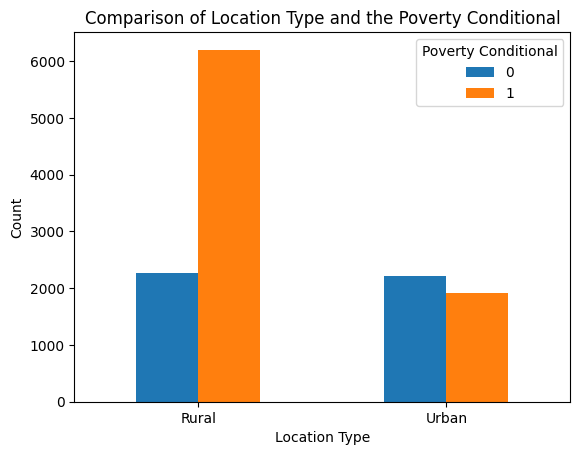

```python
# Grouping and counting the values
grouped_data = df.groupby(['is_urban', 'poverty_conditional']).size().unstack(fill_value=0)

# Creating the bar chart
ax = grouped_data.plot(kind='bar', stacked=False)
plt.xlabel('Location Type')
plt.ylabel('Count')
plt.title('Comparison of Location Type and the Poverty Conditional')
plt.legend(title='Poverty Conditional', labels=['0', '1'])
plt.xticks([0, 1], ['Rural', 'Urban'], rotation=0)

# Display the chart
plt.show()
```

The inhabitants in rural populations are more at risk of experiencing poverty conditions.

## Comparative Analysis: Exploring Poverty Conditions in Rural and Urban Spaces

### Gender

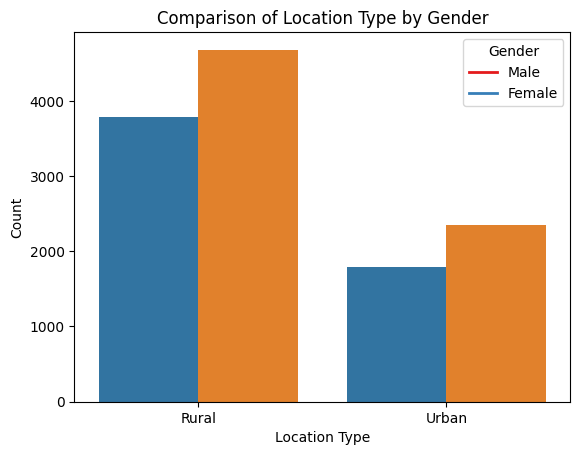

```python
# Define custom labels for 'is_urban'
is_urban_labels = {0: 'Rural', 1: 'Urban'}

# Create a countplot
g = sns.countplot(x="is_urban", hue="female", data=df)

# Set custom labels for the X-axis
g.set_xticklabels(labels=[is_urban_labels[0], is_urban_labels[1]])

# Create a custom legend using Matplotlib
legend_labels = ['Male', 'Female']
legend_handles = [plt.Line2D([0], [0], color=sns.color_palette('Set1')[i], label=label, lw=2) for i, label in enumerate(legend_labels)]

# Add the custom legend to the plot
g.legend(handles=legend_handles, title='Gender')

# Set labels and title
g.set_xlabel('Location Type')
g.set_ylabel('Count')
g.set_title('Comparison of Location Type by Gender')

# Show the plot
plt.show()
```

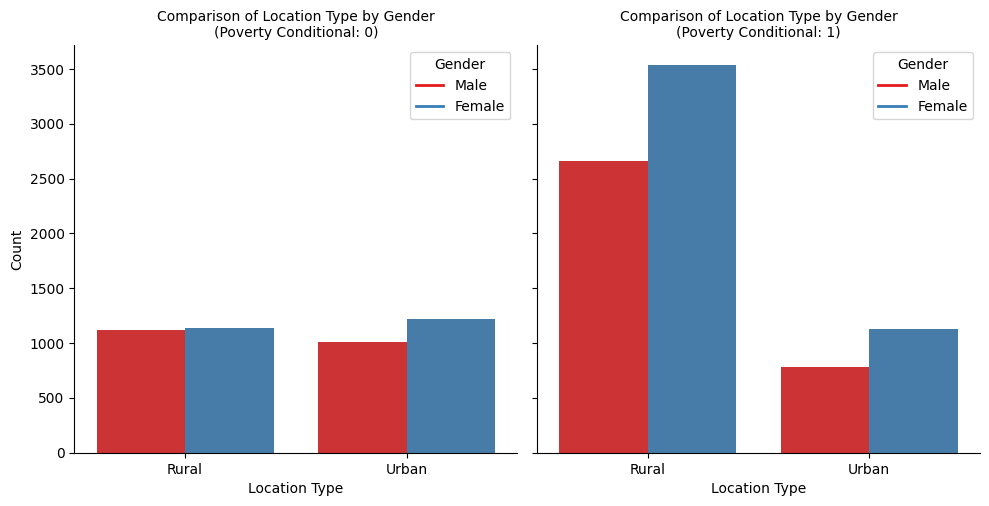

```python
# Define custom labels for 'is_urban'
is_urban_labels = {0: 'Rural', 1: 'Urban'}

# Create a countplot with 'poverty_conditional' distinction
g = sns.catplot(x='is_urban', hue = 'female' , col='poverty_conditional', data=df, kind='count', height=5, aspect=1, palette='Set1', legend = False)

# Set custom labels for the X-axis
g.set_xticklabels(labels=[is_urban_labels[0], is_urban_labels[1]])

# Create a custom legend using Matplotlib
legend_labels = ['Male', 'Female']
legend_handles = [plt.Line2D([0], [0], color=sns.color_palette('Set1')[i], label=label, lw=2) for i, label in enumerate(legend_labels)]

# Add the custom legend to the plot
for ax in g.axes.flat:
    ax.legend(handles=legend_handles, title='Gender')

# Set labels and title
g.set_axis_labels('Location Type', 'Count')
g.set_titles('Comparison of Location Type by Gender\n(Poverty Conditional: {col_name})')

# Show the plot
plt.show()
```

In rural areas, there is a significant population of both males and females at risk of poverty. Furthermore, females are disproportionately affected by poverty across all types of locations, with the disparity being even more pronounced in rural areas.

### Literacy

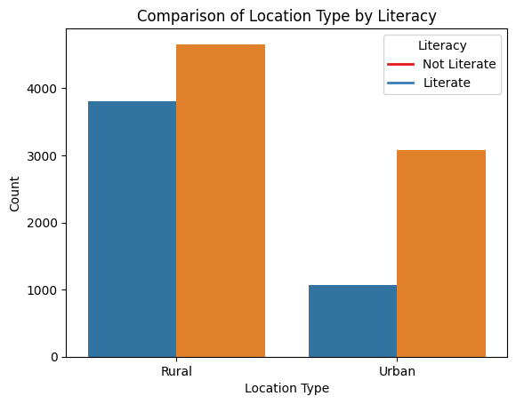

```python
# Define custom labels for 'is_urban'
is_urban_labels = {0: 'Rural', 1: 'Urban'}

# Create a countplot
g = sns.countplot(x="is_urban", hue="literacy", data=df)

# Set custom labels for the X-axis
g.set_xticklabels(labels=[is_urban_labels[0], is_urban_labels[1]])

# Create a custom legend using Matplotlib
legend_labels = ['Not Literate', 'Literate']
legend_handles = [plt.Line2D([0], [0], color=sns.color_palette('Set1')[i], label=label, lw=2) for i, label in enumerate(legend_labels)]

# Add the custom legend to the plot
g.legend(handles=legend_handles, title='Literacy')

# Set labels and title
g.set_xlabel('Location Type')
g.set_ylabel('Count')
g.set_title('Comparison of Location Type by Literacy')

# Show the plot
plt.show()
```

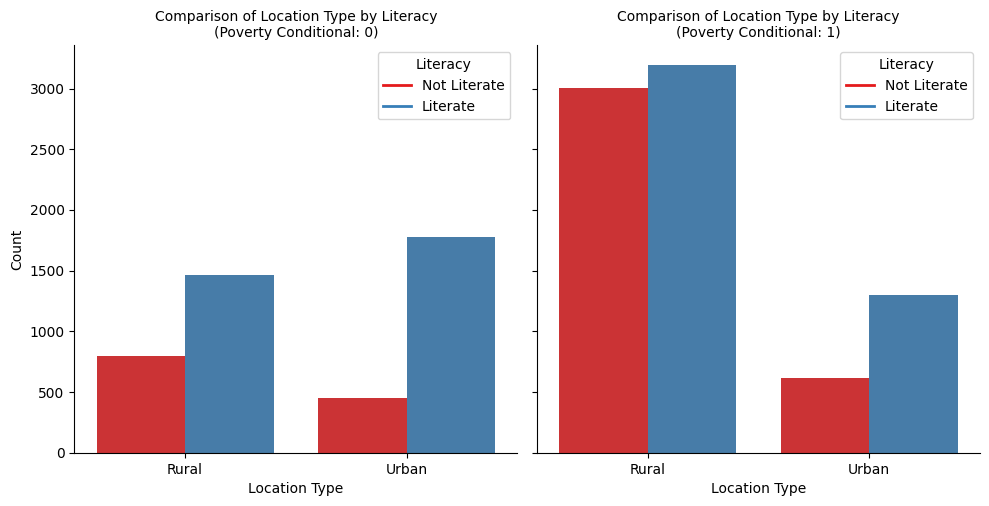

```python
# Define custom labels for 'is_urban'
is_urban_labels = {0: 'Rural', 1: 'Urban'}

# Create a countplot with 'poverty_conditional' distinction
g = sns.catplot(x='is_urban', hue = 'literacy' , col='poverty_conditional', data=df, kind='count', height=5, aspect=1, palette='Set1', legend = False)

# Set custom labels for the X-axis
g.set_xticklabels(labels=[is_urban_labels[0], is_urban_labels[1]])

# Create a custom legend using Matplotlib
legend_labels = ['Not Literate', 'Literate']
legend_handles = [plt.Line2D([0], [0], color=sns.color_palette('Set1')[i], label=label, lw=2) for i, label in enumerate(legend_labels)]

# Add the custom legend to the plot
for ax in g.axes.flat:
    ax.legend(handles=legend_handles, title='Literacy')

# Set labels and title
g.set_axis_labels('Location Type', 'Count')
g.set_titles('Comparison of Location Type by Literacy\n(Poverty Conditional: {col_name})')

# Show the plot
plt.show()
```

In rural populations, there is a considerable number of individuals who lack basic literacy skills and are vulnerable to poverty. However, it's important to note that there are also literate individuals in rural areas who also face a significant risk of poverty. Thus, the correlation between literacy and poverty in rural regions appears to be weak. Additionally, urban populations tend to have a higher proportion of literate individuals who are not at risk of poverty compared to their rural counterparts.

### Employment Category

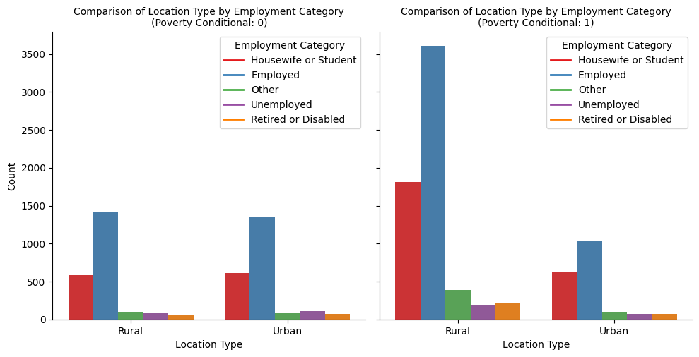

```python
# Define custom labels for 'is_urban'
is_urban_labels = {0: 'Rural', 1: 'Urban'}

# Create a countplot with 'poverty_conditional' distinction
g = sns.catplot(x='is_urban', hue = 'employment_category_last_year' , col='poverty_conditional', data=df, kind='count', height=5, aspect=1, palette='Set1', legend = False)

# Set custom labels for the X-axis
g.set_xticklabels(labels=[is_urban_labels[0], is_urban_labels[1]])

# Create a custom legend using Matplotlib
legend_labels = ['Housewife or Student', 'Employed', 'Other', 'Unemployed', 'Retired or Disabled']
legend_handles = [plt.Line2D([0], [0], color=sns.color_palette('Set1')[i], label=label, lw=2) for i, label in enumerate(legend_labels)]

# Add the custom legend to the plot
for ax in g.axes.flat:
    ax.legend(handles=legend_handles, title='Employment Category')

# Set labels and title
g.set_axis_labels('Location Type', 'Count')
g.set_titles('Comparison of Location Type by Employment Category\n(Poverty Conditional: {col_name})')

# Show the plot
plt.show()
```

The rural population at risk of poverty primarily consists of thos who were employed last year. However, there is also a significant segment of the rural population that comprises of housewives or students who typically have limited income or earnings.

#### Creating a Savings Column for Additional Comparative Analysis

```python
def savings(row):
    if row['formal_savings'] == 1:
        sav = 1
    elif row['informal_savings'] == 1:
        sav = 1
    else:
        sav = 0
    return sav
df['sav'] = df.apply(savings, axis=1)
```

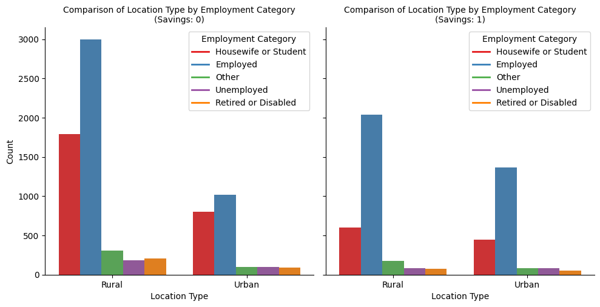

```python
# Define custom labels for 'is_urban'
is_urban_labels = {0: 'Rural', 1: 'Urban'}

# Create a countplot with 'poverty_conditional' distinction
g = sns.catplot(x='is_urban', hue = 'employment_category_last_year' , col='sav', data=df, kind='count', height=5, aspect=1, palette='Set1', legend = False)

# Set custom labels for the X-axis
g.set_xticklabels(labels=[is_urban_labels[0], is_urban_labels[1]])

# Create a custom legend using Matplotlib
legend_labels = ['Housewife or Student', 'Employed', 'Other', 'Unemployed', 'Retired or Disabled']
legend_handles = [plt.Line2D([0], [0], color=sns.color_palette('Set1')[i], label=label, lw=2) for i, label in enumerate(legend_labels)]

# Add the custom legend to the plot
for ax in g.axes.flat:
    ax.legend(handles=legend_handles, title='Employment Category')

# Set labels and title
g.set_axis_labels('Location Type', 'Count')
g.set_titles('Comparison of Location Type by Employment Category\n(Savings: {col_name})')

# Show the plot
plt.show()
```

### Education Level

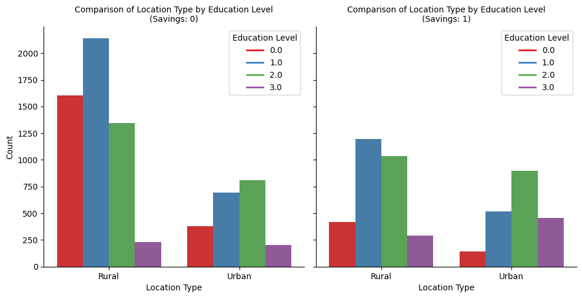

```python
# Define custom labels for 'is_urban'
is_urban_labels = {0: 'Rural', 1: 'Urban'}

# Create a countplot with 'poverty_conditional' distinction
g = sns.catplot(x='is_urban', hue = 'education_level' , col='sav', data=df, kind='count', height=5, aspect=1, palette='Set1', legend = False)

# Set custom labels for the X-axis
g.set_xticklabels(labels=[is_urban_labels[0], is_urban_labels[1]])

# Create a custom legend using Matplotlib
legend_labels = ['0.0','1.0', '2.0', '3.0']
legend_handles = [plt.Line2D([0], [0], color=sns.color_palette('Set1')[i], label=label, lw=2) for i, label in enumerate(legend_labels)]

# Add the custom legend to the plot
for ax in g.axes.flat:
    ax.legend(handles=legend_handles, title='Education Level')

# Set labels and title
g.set_axis_labels('Location Type', 'Count')
g.set_titles('Comparison of Location Type by Education Level\n(Savings: {col_name})')

# Show the plot
plt.show()
```

Among those who save, individuals with education levels categorized as 1.0 and 2.0 are more prominent than individuals with other education levels.

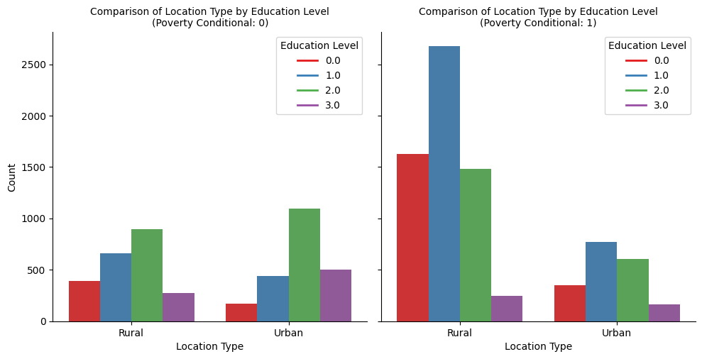

```python
# Define custom labels for 'is_urban'
is_urban_labels = {0: 'Rural', 1: 'Urban'}

# Create a countplot with 'poverty_conditional' distinction
g = sns.catplot(x='is_urban', hue = 'education_level' , col='poverty_conditional', data=df, kind='count', height=5, aspect=1, palette='Set1', legend = False)

# Set custom labels for the X-axis
g.set_xticklabels(labels=[is_urban_labels[0], is_urban_labels[1]])

# Create a custom legend using Matplotlib
legend_labels = ['0.0','1.0', '2.0', '3.0']
legend_handles = [plt.Line2D([0], [0], color=sns.color_palette('Set1')[i], label=label, lw=2) for i, label in enumerate(legend_labels)]

# Add the custom legend to the plot
for ax in g.axes.flat:
    ax.legend(handles=legend_handles, title='Education Level')

# Set labels and title
g.set_axis_labels('Location Type', 'Count')
g.set_titles('Comparison of Location Type by Education Level\n(Poverty Conditional: {col_name})')

# Show the plot
plt.show()
```

Those at risk of poverty primarily have an education level value of 0.0, 1.0, or 2.0.

#### Creating a Borrowed column

```python
def borr(row):
    if row['borrowed_for_emergency_last_year'] == 1:
        borrowed = 1
    elif row['borrowed_for_daily_expenses_last_year'] == 1:
        borrowed = 1
    elif row['borrowed_for_home_or_biz_last_year'] ==1:
        borrowed = 1
    else:
        borrowed = 0
    return borrowed
df['borrowed'] = df.apply(borr, axis=1)
df['borrowed'].value_counts()
```

```
borrowed
0    8587
1    4013
Name: count, dtype: int64
```

### Borrowings

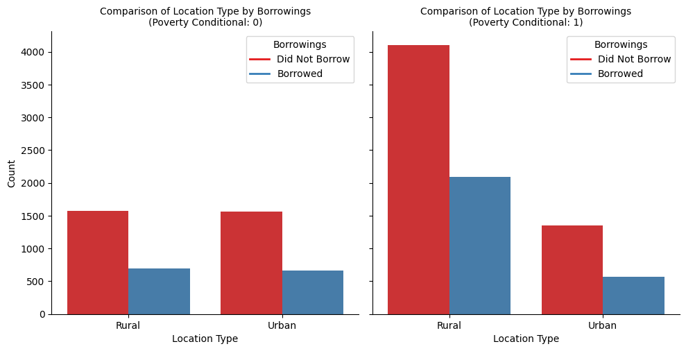

```python
# Define custom labels for 'is_urban'
is_urban_labels = {0: 'Rural', 1: 'Urban'}

# Create a countplot with 'poverty_conditional' distinction
g = sns.catplot(x='is_urban', hue = 'borrowed' , col='poverty_conditional', data=df, kind='count', height=5, aspect=1, palette='Set1', legend = False)

# Set custom labels for the X-axis
g.set_xticklabels(labels=[is_urban_labels[0], is_urban_labels[1]])

# Create a custom legend using Matplotlib
legend_labels = ['Did Not Borrow','Borrowed']
legend_handles = [plt.Line2D([0], [0], color=sns.color_palette('Set1')[i], label=label, lw=2) for i, label in enumerate(legend_labels)]

# Add the custom legend to the plot
for ax in g.axes.flat:
    ax.legend(handles=legend_handles, title='Borrowings')

# Set labels and title
g.set_axis_labels('Location Type', 'Count')
g.set_titles('Comparison of Location Type by Borrowings\n(Poverty Conditional: {col_name})')

# Show the plot
plt.show()
```

Among those at risk of poverty, majoirty of the rural population did not borrow. However, there are around 2,000 entries from the rural population vulnerable to poverty that did borrow.

### Age Group

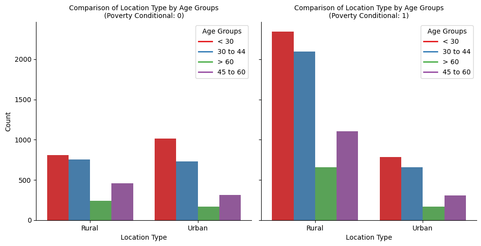

```python
# Define custom labels for 'is_urban'
is_urban_labels = {0: 'Rural', 1: 'Urban'}

# Create a countplot with 'poverty_conditional' distinction
g = sns.catplot(x='is_urban', hue = 'age_group' , col='poverty_conditional', data=df, kind='count', height=5, aspect=1, palette='Set1', legend = False)

# Set custom labels for the X-axis
g.set_xticklabels(labels=[is_urban_labels[0], is_urban_labels[1]])

# Create a custom legend using Matplotlib
legend_labels = ['< 30','30 to 44', '> 60', '45 to 60']
legend_handles = [plt.Line2D([0], [0], color=sns.color_palette('Set1')[i], label=label, lw=2) for i, label in enumerate(legend_labels)]

# Add the custom legend to the plot
for ax in g.axes.flat:
    ax.legend(handles=legend_handles, title='Age Groups')

# Set labels and title
g.set_axis_labels('Location Type', 'Count')
g.set_titles('Comparison of Location Type by Age Groups\n(Poverty Conditional: {col_name})')

# Show the plot
plt.show()
```

The most prominent populations that are at risk for poverty are rural populations that are younger than 30 years and those that are between age 30 to age 44.

#### Linear Regression Model

```python
from statsmodels.formula.api import ols

# Create the linear regression model
model = ols('poverty_probability ~ age + C(female)', data=df)

# Fit the model
fitted_model = model.fit()

# Display the summary
fitted_model.summary()
```

OLS Regression Results

| Dep. Variable: | poverty_probability | R-squared: | 0.003 |
| --- | --- | --- | --- |
| Model: | OLS | Adj. R-squared: | 0.003 |
| Method: | Least Squares | F-statistic: | 21.96 |
| Date: | Thu, 21 Sep 2023 | Prob (F-statistic): | 3.03e-10 |
| Time: | 17:34:48 | Log-Likelihood: | -2322.9 |
| No. Observations: | 12600 | AIC: | 4652. |
| Df Residuals: | 12597 | BIC: | 4674. |
| Df Model: | 2 |  |  |
| Covariance Type: | nonrobust |  |  |

|  | coef | std err | t | P>\|t\| | [0.025 | 0.975] |
| --- | --- | --- | --- | --- | --- | --- |
| Intercept | 0.5847 | 0.007 | 78.158 | 0.000 | 0.570 | 0.599 |
| C(female)[T.1] | 0.0344 | 0.005 | 6.577 | 0.000 | 0.024 | 0.045 |
| age | 0.0002 | 0.000 | 1.184 | 0.236 | -0.000 | 0.001 |

| Omnibus: | 2677.598 | Durbin-Watson: | 1.996 |
| --- | --- | --- | --- |
| Prob(Omnibus): | 0.000 | Jarque-Bera (JB): | 906.757 |
| Skew: | -0.451 | Prob(JB): | 1.26e-197 |
| Kurtosis: | 2.044 | Cond. No. | 121. |

Notes:  
[1] Standard Errors assume that the covariance matrix of the errors is correctly specified.

### Exploring Relationships Among Age, Financial Activities, and Poverty Probability

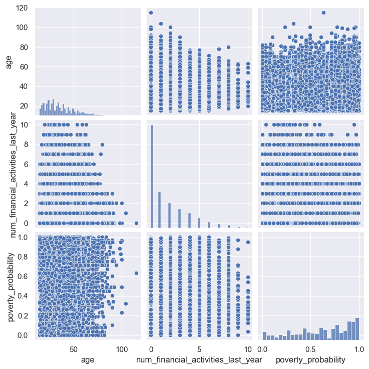

```python
num_cols = ['age', 'num_financial_activities_last_year', 'poverty_probability']
sns.set(style= 'darkgrid')
sns.pairplot(df[num_cols])
```

#### Correlation Heatmap

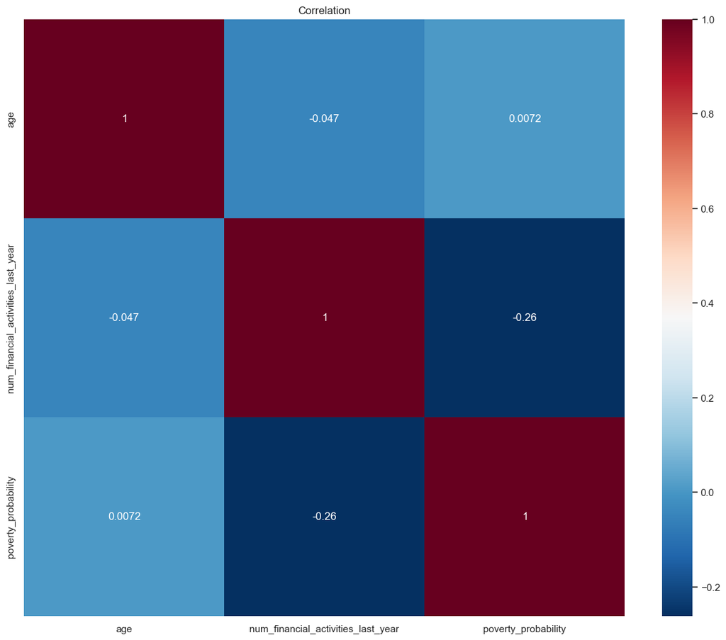

```python
plt.figure(figsize=(15,12))
sns.heatmap(df[num_cols].corr(),annot=True,cmap= 'RdBu_r')
plt.title('Correlation')
plt.show()
```

```python
export_csv = df.to_csv('export_df.csv', index = None, header = True)
```